# Tresthor *Package R pour la prévision économique* Rapport de performance de l’utilisation de Tresthor dans le cadre de l’économie Polynésienne

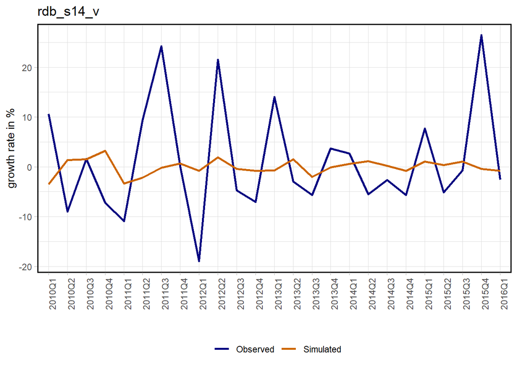

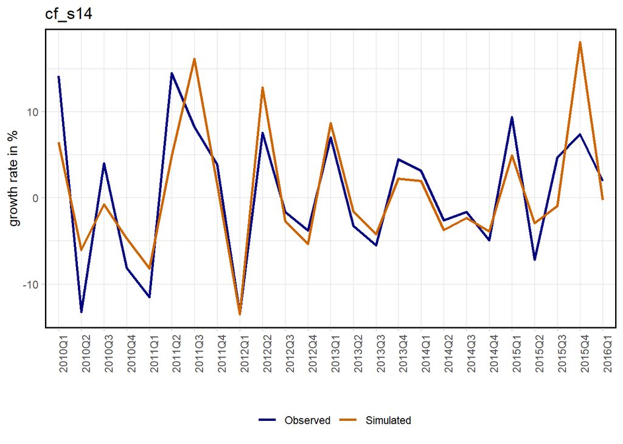

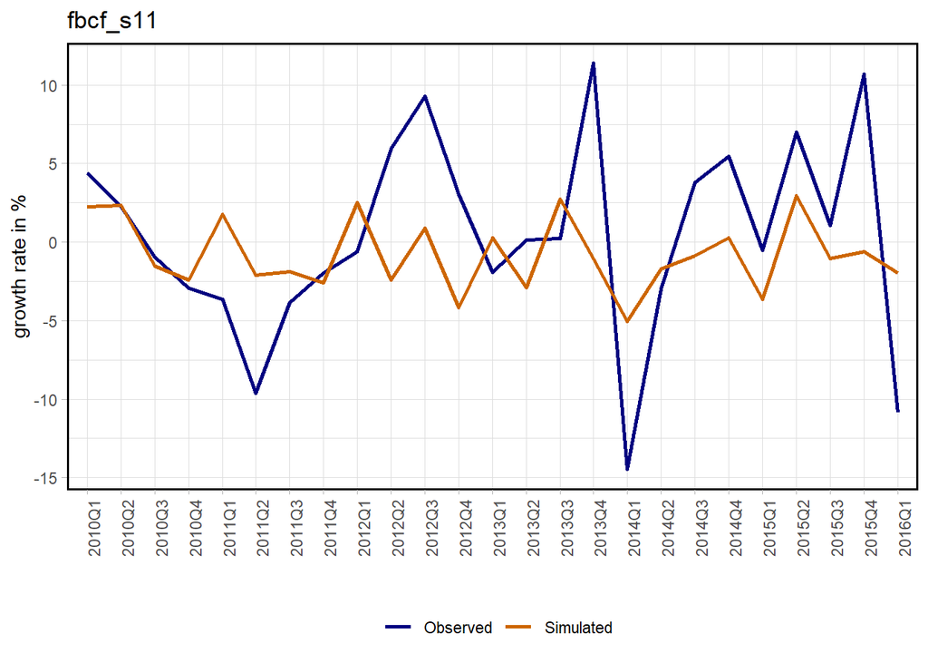

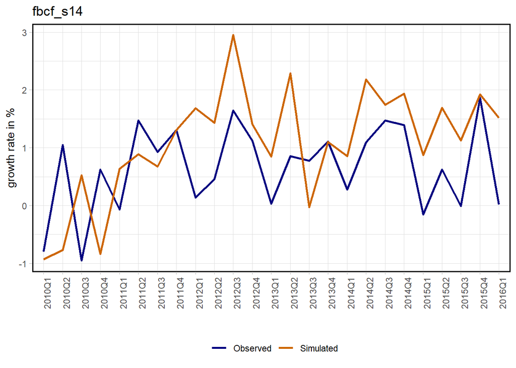

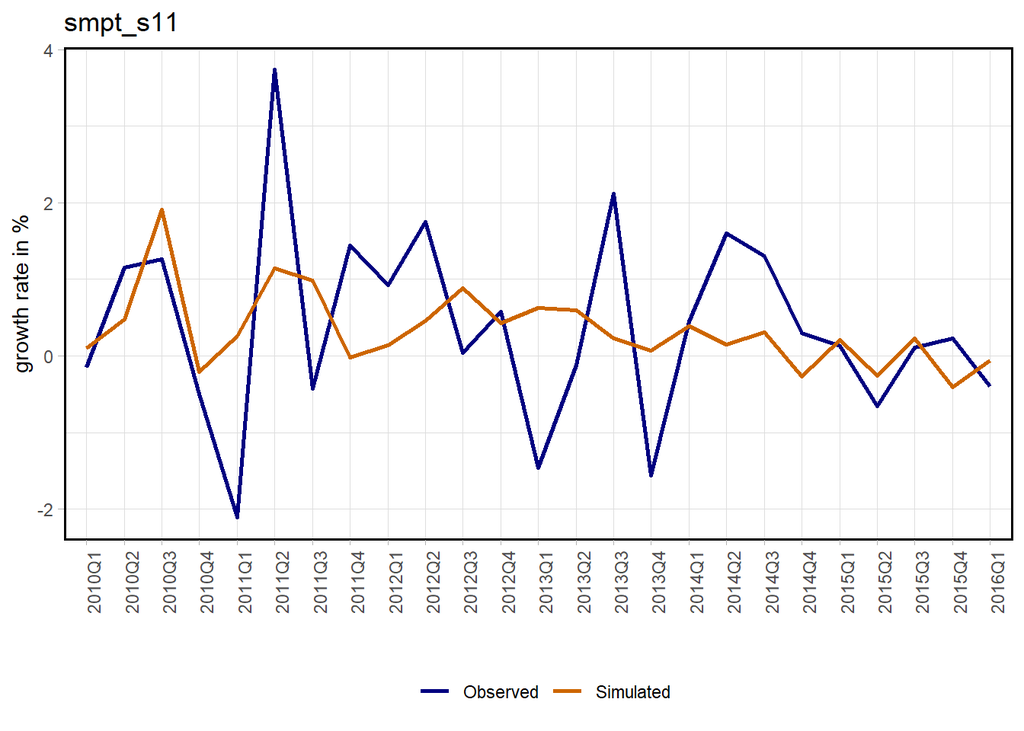

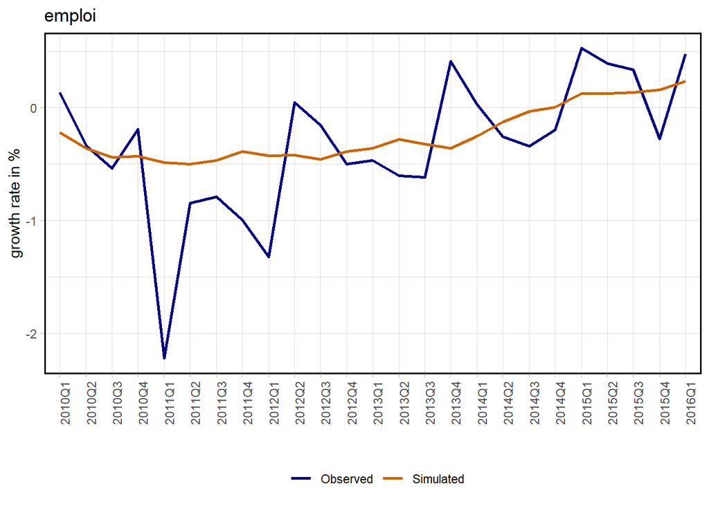

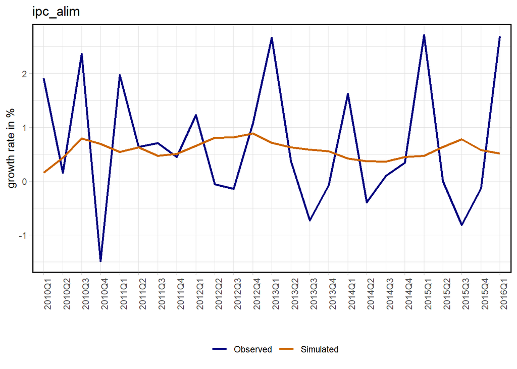

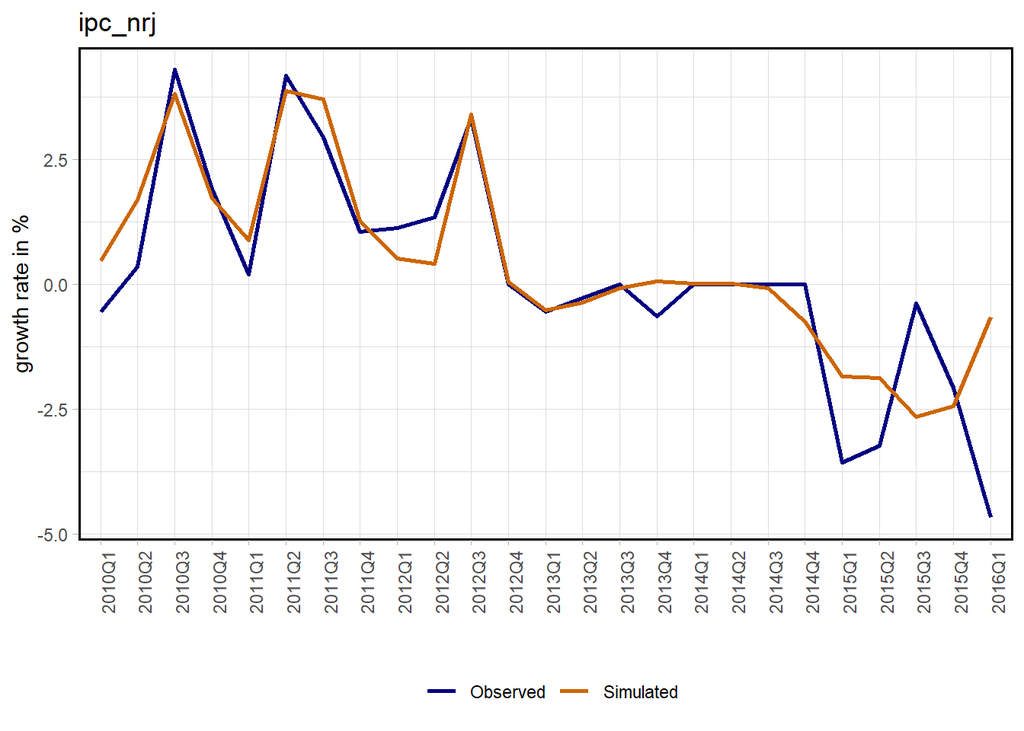

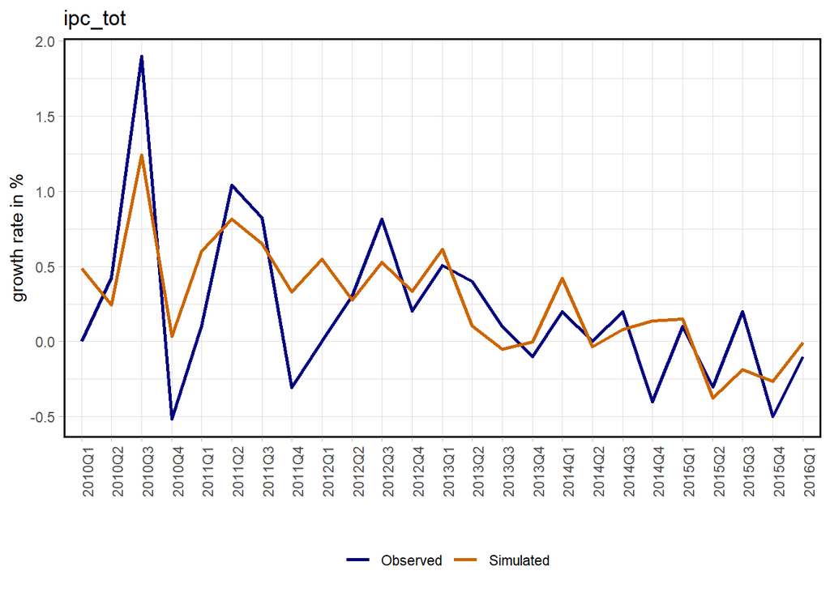

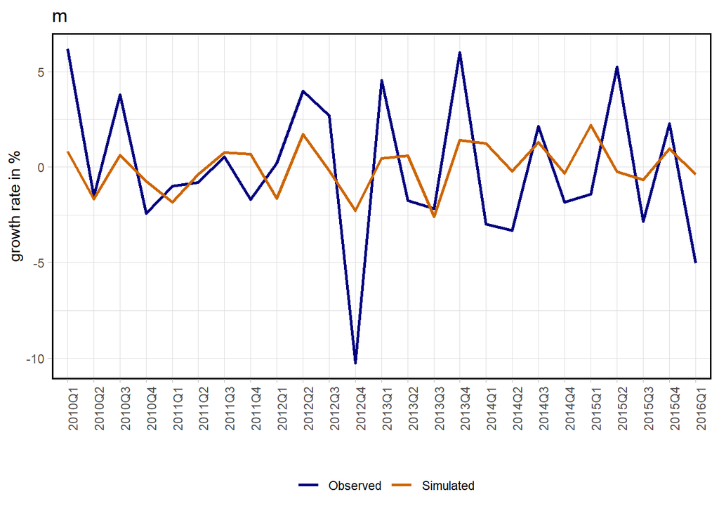

```r
lapply(1:length(info_equations), function(x) {
  graph_sim_obs(
    simul_data[[x]] ,
    start_plot = as.Date(date_debut_simulation),
    end_plot = as.Date(date_fin_simulation),
    title = paste0(info_equations[[x]]$endogenous_name),
    type = "g"
  )
})
```

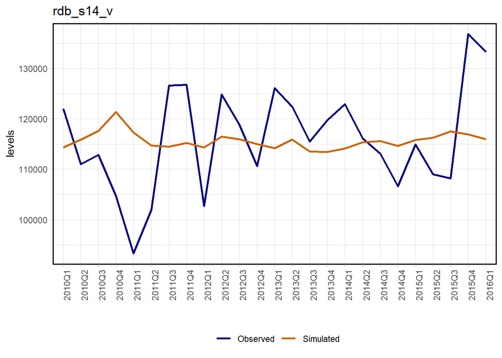

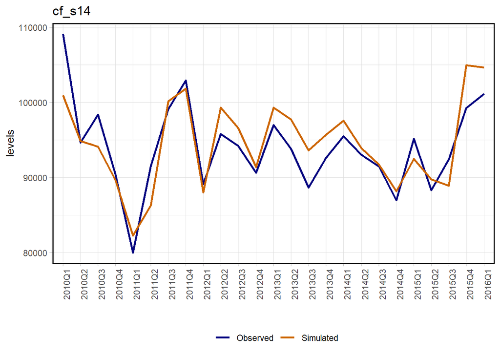

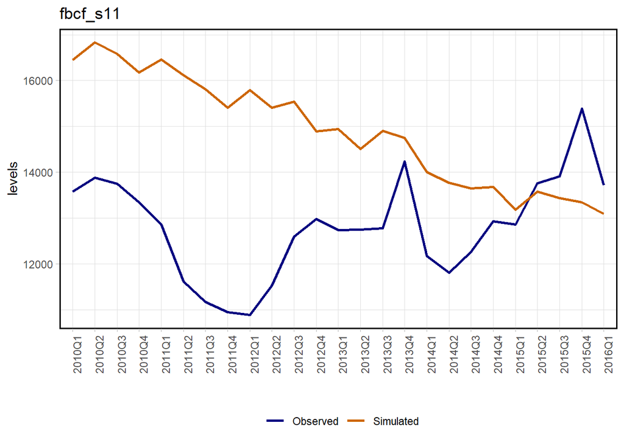

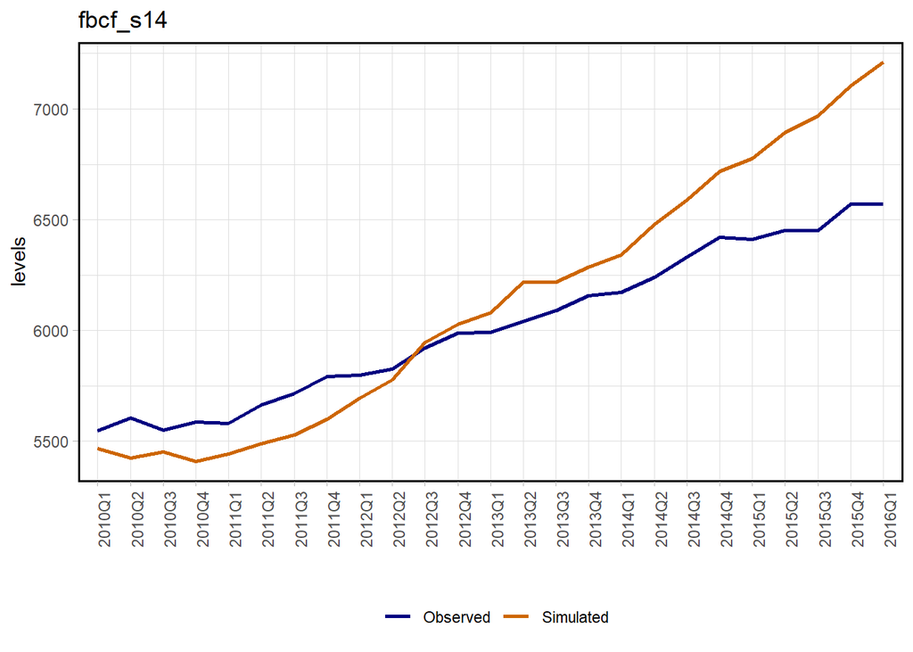

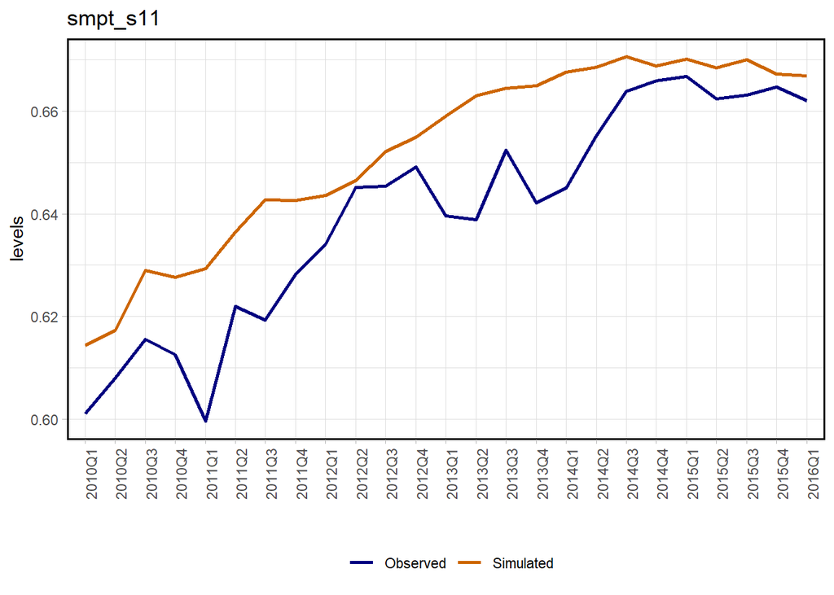

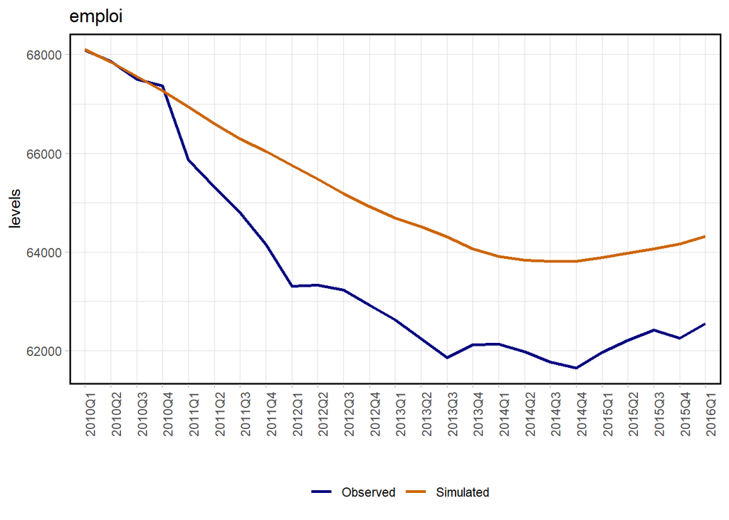

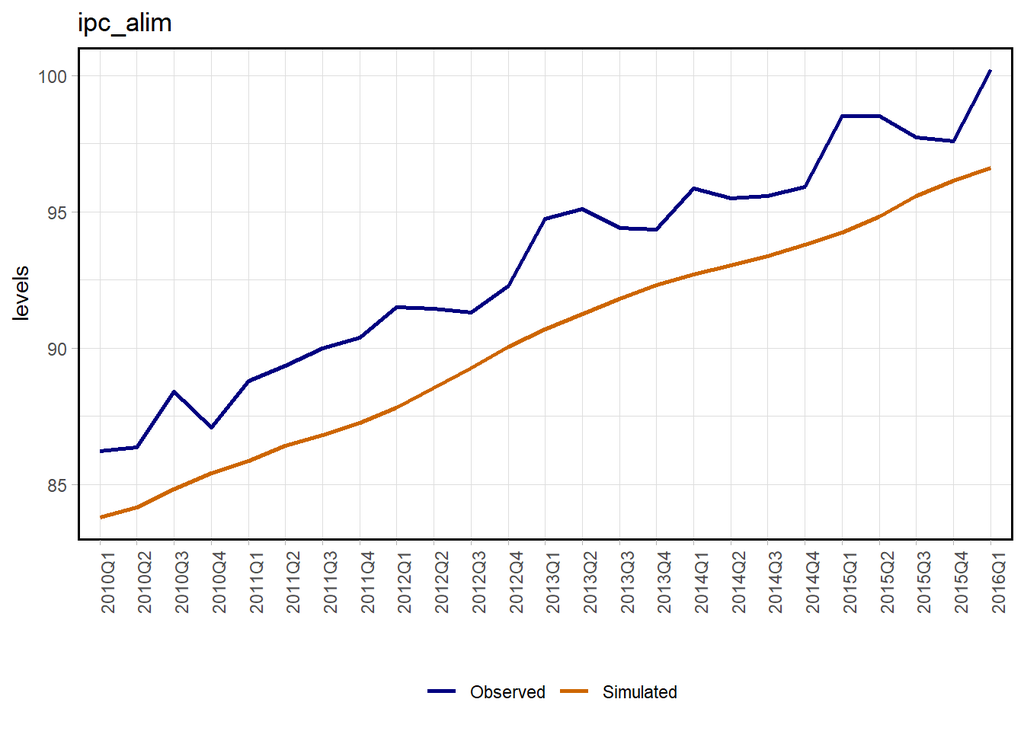

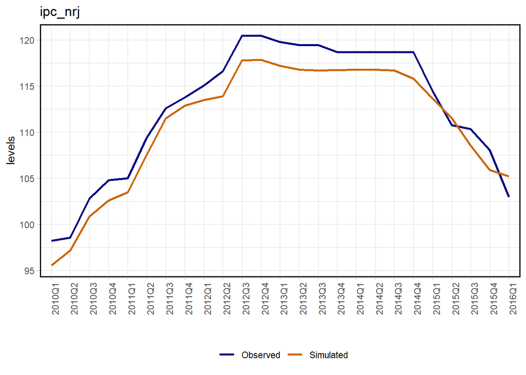

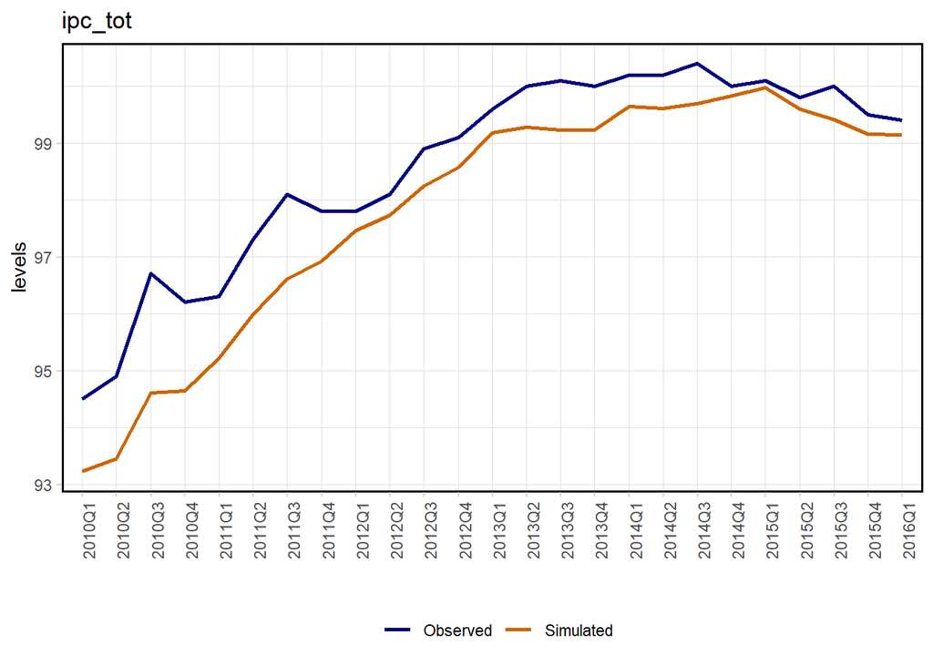

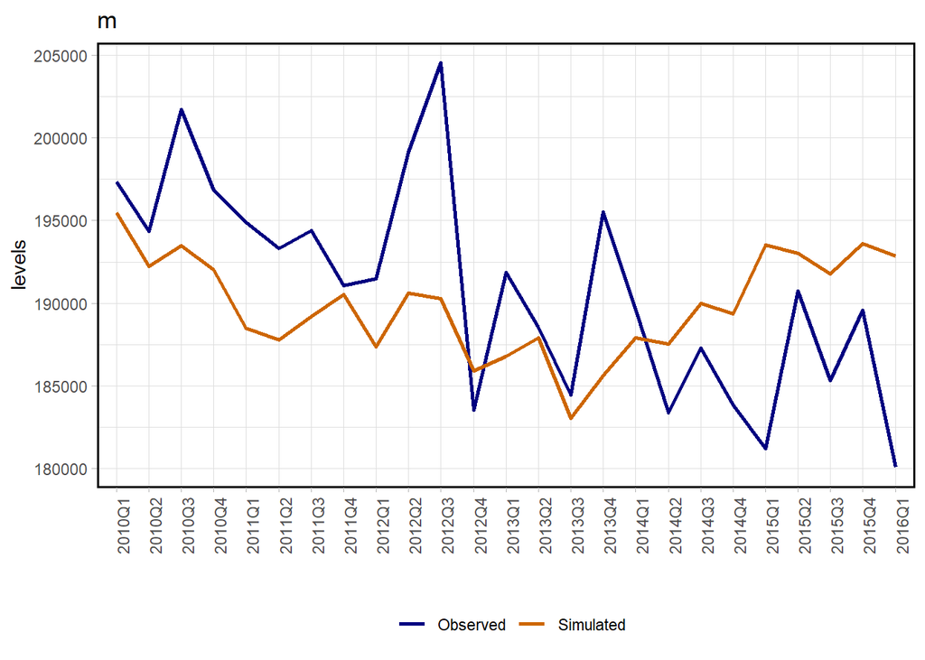

```r
lapply(1:length(info_equations), function(x) {
  graph_sim_obs(
    simul_data[[x]] ,
    title = paste0(info_equations[[x]]$endogenous_name),
    start_plot = as.Date(date_debut_simulation),
    end_plot = as.Date(date_fin_simulation),
    type = "lvl"
  )
})
```

Il faut noter que les présentation graphique concernant les contribution des variables explicatives aux *endogènes* et les comparaisons simulées/observées ne peuvent être construite qu’à partir d’équations économétriques. Ceci peut poser problème pour la présentation du PIB mais il devrait être aisé de détourner ce problème en créant une fausse équation économétrique pour le PIB incluant des coefficients définit à 1 et les variations de stocks comme résidu de l’équation.

## 6.4 Les graphiques de visualisation de courbes rapides : quick_plot()

La fonction quick_plot() permet visualiser rapidement plusieurs variables d’une même base de données, en niveau ou en taux de croissance.

- `variables` : variables à tracer
- `database` : la base de données où trouver ces variables
- `start` et `end` : pour indiquer quand commence et termine le graphique
- `index_time` : le nom de l’indicateur temporel de la base de données
- `growth_rate` : TRUE si on veut tracer les taux de croissance, sinon ce sera en niveau (par défaut FALSE)
- `title` : le titre à donner au graphique
- `colours` : un vecteur de couleurs pour personnaliser les couleurs des courbes. Il faut spécifier au minimum autant de couleurs que de variables, les couleurs en trop seront ignorées. Si un nombre insuffisant de couleurs est spécifié, les couleurs par défaut seront utilisées

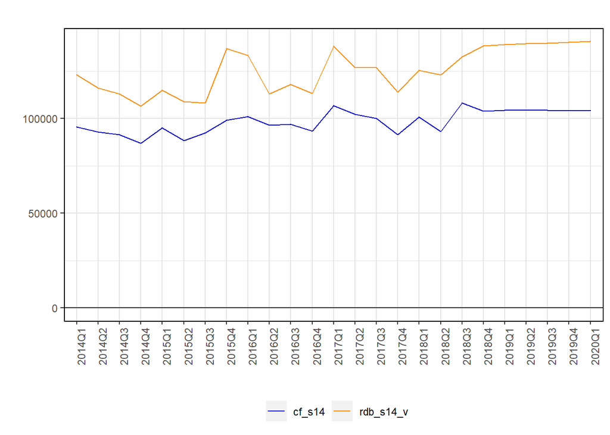

```r
#Exemple avec la consommation et l'investussement des ménages

prev[,"date"]<-as.Date(prev[,"date"])
quick_plot(c("rdb_s14_v", "cf_s14"),
           prev,
           start = as.Date("2014-03-31"),
           end = as.Date("2020-03-31"))
```

# 7 Les grands travaux à venir

Travaux à venir par ordre d’importance:

- Revoir les retraitements de données, la cohérence du cadre comptable et les problèmes précis comme l’investissement d’avions
- Ajouter les observations des variables manquantes (variables en volume, RDB, …)
- Revoir la cohérence économique des équations économétriques et du partage volume/prix dans le modèle et réaliser les tests économétriques avec les données arrêtées
- Ajouter des variables (heures travaillées par emploi, taux de chômage, …) afin d’améliorer les spécifications des équations économétriques
- Améliorer le modèle en désagrégeant les grands indicateurs (e.g. en dissociant les biens des services)
- Tester différents scénarios sur un exercice post mortem et vérifier la robustesse des équations
- Faire essayer l’outil à un prévisionniste avec ses hypothèses pour les variables exogènes

# 8 Les étapes à valider dans le cas général

- Avoir des données et un modèle qui permettent de rapprocher les simulations (qui sont établies avec les variables exogènes observé) de l’histoire économique
- Etre capable de faire une prévision sur une période passée (sans crise non prévisible) qui colle avec la réalité avec des hypothèses tenables sur les variables exogènes et qui colle également avec le simulé.
- Etre capable de faire une prévision sur le futur avec des données qui ne sont pas encore définitive (compte définitifs non disponibles sur les périodes récentes)

# 9 Comment modifier le programme

Nous décrivons ici un seul processus mais d’autres pourraient y être ajoutés à l’avenir.

## 9.1 Ajout d’une nouvelle équation dans le modèle

1<sup>ère</sup>étape : modifier le modèle en ajoutant l’équation (étape non obligatoire (pour rester cohérent avec le travail décrit) : ajouter l’équation à une ligne où elle est logiquement calculable par rapport aux lignes plus hautes), veiller à incorporer les nouvelles variables dans “endo” ou “exo” et “coeff” si l’équation en possède. Si c’est une équation économétrique à MCE, alors ne pas oublier de rajouter l’équations des résidus endogènes.

2<sup>ème</sup> étape : exécuter la fonction `create_model()` afin de s’assurer que l’équation a correctement été insérée dans le modèle. Attention : il faut enregistrer le fichier `.txt` pour effectivement créer le nouveau modèle. S’il il y a une erreur cela peut venir (liste non exhaustive) :

- Le système d’équations ne possède pas autant de variable *endogènes* que d’équations : vérifier si dans l’équation intégrée il n’y a qu’une seule *endogène* qui est déterminée par l’équation.
- Toutes les variables n’ont pas été classifiées correctement dans une des 3 catégories
- Problème de syntaxe : se référer au [guide de l’utilisateur](https://www.tresor.economie.gouv.fr/Content/other/Opale/manuel_tresthor.html)

3<sup>ème</sup> étape : Inclure les données des nouvelles variables ajoutées dans dt_pf :

- Si la variable est *exogène* : s’assurer de détenir les données nécessaire à son utilisation, i.e données complètes sur la période d’estimation si présente dans une équation économétrique pour l’estimation et la simulation et données complètes sur la dernière période avant prévision pour la prévision. Effectuer la trimestrialisation/CVS/CJO. Puis faire une hypothèse de scénario sur cette variable sur la période de prévision pour la prévision (possiblement en la classifiant dans une de nos deux catégories)
- Si la variable est *hybride* : s’assurer de détenir les données nécessaire à son utilisation, i.e données complètes sur la période d’estimation et simulation et données complètes sur la dernière période avant prévision pour la prévision. Effectuer la trimestrialisation/CVS/CJO.
- Si la variable est *endogène* : détenir les données nécessaires à son utilisation ou les initialiser dans l’étape d’“Initialisation”. Si la variable est dans le membre de droit d’une équation économétrique alors obtenir les données de cette variable sur toute la période d’estimation et de simulation. De plus, dans tous les cas, obtenir les données sur la dernière période avant prévision pour la prévision.

4<sup>ème</sup> étape :

- Si c’est une équation comptable : inclure l’équation dans l’étape d’initialisation de la façon appropriée si cela est nécéssaire
- Si c’est une équation économétrique : ajouter les informations nécessaires dans `info_equations`

# 10 Principales erreurs rencontrées lors de l’éxécution

- `Error in while (sum(abs(x_n1 - x_n) > c(rep(epsilon, length(x_n)))) > : missing value where TRUE/FALSE needed` : l’origine de cette erreur est très compliqué à sourcer. Elle est majoritairement la conséquence d’un problème dans l’étape d’initialisation. Par exemple, cette erreur peut survenir si les données d’une des variable créées dans l’étape d’initialisation ne sont pas à la bonne échelle.

Un point important à souligner est de veiller à exécuter l’ensemble du programme après avoir nettoyer intégralement l’environnement après chaque modification majeure. Il est beaucoup plus facile de sourcer un problème (qui peut survenir sur une partie du code totalement différente de celle modifiée) quand on connait la modification qui a entraîner l’erreur. L’utilisation d’un contrôle de version permet bien sûr également de veiller à maintenir le programme toujours utilisable.

# 11 A faire

Problèmes .Rmd :

Comment, dans le menu déroulant n’afficher que les grand titres, puis les plus petit en passant la souris dessus? comme dans les html de la DG Comment faire référerence à d’autres parties du rapport avec un lien? Il y a t’il des codes permettant de créer un dictionnaire?

[^1]: C’est en fait un abus de langage car un MCE consiste à corriger le résidu et non pas l’erreur
[^2]: Méthode Denton-Cholette : voir https://www150.statcan.gc.ca/n1/pub/12-001-x/2018001/article/54927/02-fra.htm et https://journal.r-project.org/archive/2013-2/sax-steiner.pdf et https://cran.r-project.org/web/packages/tempdisagg/vignettes/intro.html
[^3]: Nous essayerons de lister les arguments de chaque fonction spéciale utilisée. Cependant la liste ne sera pas toujours exhaustive, d’autres options peuvent compléter l’utilisation des fonction.